# Linear Regression Modeling

Maria Berroa

2025-04-13

#### **Problem 1 - Regression Warm-Up**

##### For a 55-year old, we should expect a creatinine clearance rate of about 113.72 mL/minute. To determine this, we fit a linear model to our data and obtain the coefficients for the equation. In this case our coefficients are 147.81 and -0.62. The first telling us our baseline and the second one the effect of age. This gives us the equation **y = 147.81 - 0.62x**, where y represents the expected value and x represents age.

##### A one-year increase in age is associated with a **-0.62 mL/minute** change in creatinine clearance rate, on average. This means that as you age, the creatinine clearance rate decreases by -0.62 mL/min. I determined this by obtaining the coefficients from my fitted model. The second coefficient represents the rate of change with age - or the slope of the linear model.

##### To determine who has a higher creatinine clearance rate for her age, we calculate the residuals, which are defined as: actual rate - predicted rate. By doing so, we find that the 40-year old person’s creatinine clearance rate (residual) is **11.98 mL/min** above average for her age. In contrast, the 60-year old’s creatinine clearance rate (residual) is **1.38 mL/min** above average for her age. Therefore, for her age, the 40-year-old person has a higher creatinine clearance rate. (More detailed equations are on the R file.)

#### **Problem 2 - Modeling disease growth**

##### **1.**

##### After analyzing our data, we estimate that the daily growth rate for COVID-19 cases in Italy is approximately 0.183, and we are 95% confident that the true value lies between 0.159 and 0.209. We also estimate that the doubling time for COVID-19 cases is about 3.8 days, and we are 95% confident that the true value lies between 3.3 and 4.3 days.

##### **2.**

##### After analyzing our data, we estimate that the daily growth rate for COVID-19 cases in Spain is approximately 0.276, and we are 95% confident that the true value lies between 0.234 and 0.317. We also estimate that the doubling time for COVID-19 cases is about 2.5 days, and we are 95% confident that the true value lies between 2.2 and 3.0 days.

##### **3.**

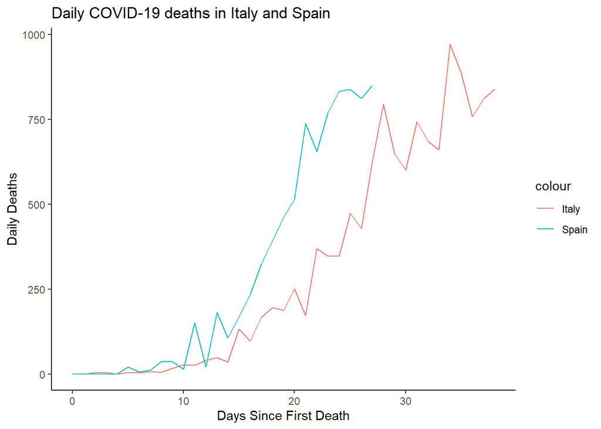

#### **Problem 3 - Price Elasticity of Demand**

##### The estimated price elasticity of demand for milk is -1.62, meaning that when the price of milk increases by 1%, consumers purchase approximately 1.62% less of it. We are 95% confident that the true value lies between -1.77 and -1.45. To estimate the price elasticity, I used a power - law model, which involved taking the logarithm of both variables - price and sales. I then applied bootstrapping to this model in order to obtain the confidence interval